None

# Table of Contents

## Introduction to Finite State Machines

Robots, factories, AI characters in a video game, traffic lights, microwaves and digital watches all require a control system to "decide" what the machine/software/system is doing at any moment.

In this class you will need to develop robots that interact with their environment in a variety of ways, so you will need to learn how to implement "decision-making" processes for your robots. This will mean controlling when to move, when to stop and when to turn, for example.

The video below is an example of the kind of control you will learn.

[video not shown]

## Why model a system as a Finite State Machine (FSM)?

Many systems that abruptly transition from one set of behaviors to another (including robots, but also people, animals, machines, or other artificial intelligence systems) can be well-modeled as Finite State Machines (FSMs). This type of system often does not exhibit just one prototypical type of [dynamic behavior](https://alexanderallenbrown.github.io/ES103_SP22_Students/Reading_01/Reading_01.html#What-is-a-DYNAMIC-System?), so is therefore poorly suited to a single ES103-style physical dynamic model. A FSM model can describe the "jumps" between prototypical behaviors of a system or machine.

**Note: Systems that abruptly transition from one type of dynamic behavior to another using FSM-like "jumps" are called *hybrid dynamic systems*. A robot that both turns and moves forward is a good example. Being fluent in dynamic modeling (ala ES103) and discrete FSM models together will broaden your modeling palate considerably, because you will be able to model systems that are FSM-like, dynamic, or hybrid!**

So what type of systems are candidates for an FSM model? We don't need to look far. Let's say you wanted to use a finite state machine to model a *human*'s behavior when they are either asleep or awake. We begin by thinking about what a brain does based on our experiences and see if that can get us started. If you start to think about what the brain does... it turns out it does a lot!

However, at this point we are **NOT** trying to make the **best** model of a brain, we are just trying to come up with any **reasonable model**. So lets begin with the simplest model we can come up with and then we can increase the complexity later if needed.

That means we MUST make assumptions about how much of the complexity of the real system we'll capture in our model. As engineers we need to do this in ALL situations and ALL times. We will never model a real system EXACTLY. A model will always be some kind of approximation and that is ok if it captures behaviors we care about, and is *predictive* of the system's behavior within the bounds we wish to model. This ethos is captured well the following 1991 paper by philosopher Daniel Dennett called ["Real Patterns."](https://ruccs.rutgers.edu/images/personal-zenon-pylyshyn/class-info/FP2012/FP2012_readings/Dennett_RealPatterns.pdf). Dennett casts the problem of simplification of actual phenomena in terms of pattern recognition, but the idea is the same: **simplified engineering models of dynamic systems are valuable if they are *predictive* over the range of inputs we suspect the system will see**.

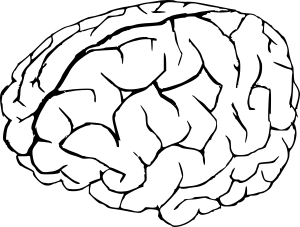

To get started we'll need to think about a very basic behavior of the brain. Even then there are A LOT of choices, but we will assume that the brain moves between only two "situations": Being awake and being asleep. Like your experience modeling systems in ES103, we need to have some idea of how the system dynamically moves between these two situations. We probably don't have a lot of knowledge about the physiology of the brain, but we do have some common system modeling experience. Using that we could propose the following brain response behavior:

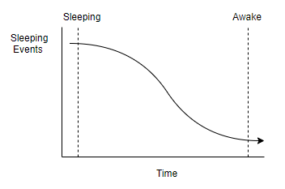

## *System Model Validation*

With a model in hand, is there any way we can assess its validity? Do we have data or theory to "test" it? Sometimes we might have previous experience and/or data we can draw on, but in this case we would likely need to seek out new knowledge. A brief search of articles identified [this article](https://onlinelibrary.wiley.com/doi/pdf/10.1111/j.1469-8986.1994.tb02213.x?casa_token=fU87PN4Y0t0AAAAA:x0yUzuBV3L1Kg-9u6sb7jrcbsb6MCuqVNJD7Wgzx7Oiz3Rkoo5KvoqZDcOlrmKy4nc3p6WJDqf3MLbo) as a potential resource.

The authors looked at the ability of participants to perform a task (lifting their finger when a "target tone" was heard) as they fell asleep. The data for the participants' ability to do this is shown in the figure below, which was pulled from the paper text.

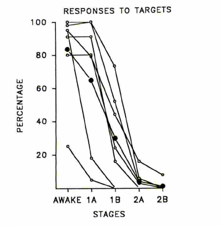

This is interesting, and it does appear that as time goes on and brainwave activity indicates the participants are falling into sleep, their ability to respond to the task follows a curve that looks (roughly, if you squint) like our model!

### Finite State Machine (FSM) Model

However, to keep this model as simple as possible we could say "we assume the time it takes to transition between sleeping and awake is short enough that we aren't interested in the details of the transition". This means that we would only practically be interested in whether the brain was "sleeping" or "awake" as the transition would be so short it wouldn't be of interest.

This type of model is very common and allows you to represent different "situations" as Boolean States. A **FINITE STATE MACHINE** is a model that is always in a defined **Boolean State** and the time to transition between the states is neglected.

**Each of the "Boolean States" in a finite state machine can take only one of two values:**

- True (the machine is in this state)
- False (the machine is not in this state)

**If you use a finite state machine to model your system then two assumptions are required**

- The number of Boolean states is **finite**, meaning that you can count them.
- A Finite State Machine can be only be allowed to be in **one Boolean state at a time.**

*Note that we are using the term "Boolean State" to distinguish from the "state" you're familiar with from system dynamics used in "state space" models, which corresponds with a system's energy state.*

What do these mean for the brain model? It means that if we were to develop a Finite State Machine **(FSM)** model of your brain, we would be asserting that your brain cannot be both asleep and awake at the same time. It would be reasonable to say that a brain model needs more than two states, but this is only a *model*. If more complex behavior is revealed to be important as you validate your controller design, than more states can always be added to the model.

## *FSM Design*

Now that we know how your system behaves, we need to design an implementation of our FSM model that will allow us to dictate when and how it does those things.

To begin developing tools for the design of Finite State Machines, we can create a **State Transition Diagram**.

### FSM State Transition Diagrams

A state transition diagram is a *design tool* for FSMs that allows you to organize how your system will move from one state to another. It consists of bubbles representing each Boolean state, and arrows that show how the system is permitted to move between those Boolean states. A generic example is shown below-- note that it is not possible for the system to move from state 3 to state 1!

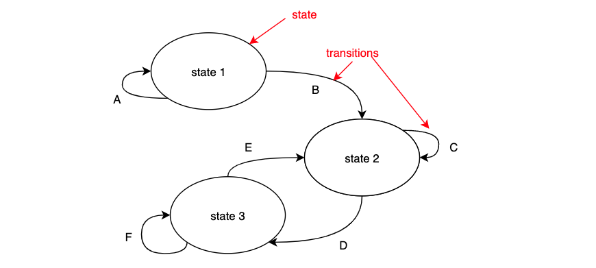

The details of how to set up a state transition diagram are best learned by example, so let's continue with the Sleeping/Awake model of the brain.

Here each Boolean state of our brain model is shown as its own bubble as seen below.

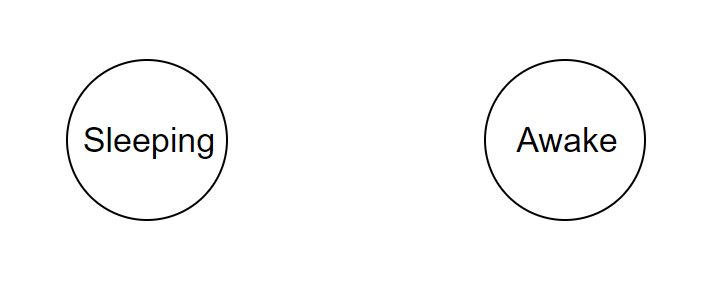

### FSM - INPUTS, STIMULI (CONDITIONS) and TRANSITIONS

In general, it takes some kind of "stimulus" to cause a state machine to leave one Boolean state and go to the other. In our brain model the stimulus that brings you from "Sleeping" to "Awake" might be an alarm going off for your 8AM class. The transition from "Awake" to "Asleep" might be described by the condition that "you're tired and it's past your bedtime."

There are two types of stimuli that we will deal with in ES302:

1. **Inputs (stimuli from the user/outside world)**
2. **Internal Stimuli (e.g. a timer internal to the robot's control software)**

Inputs are often things like switches, buttons, distance sensors, and control panels on a robot. "Timers" in an FSM program keep track of how long it's been since some event has occurred, and "Counters" keep track of how many times something has happened. You'll learn about those later in this notebook.

The diagram below indicates how the arrow and transition condition indicates what happens if the brain is the *Sleeping* state AND the "alarm goes off" transition condition occurs. The brain will change to the *Awake* state. EVERYTHING shown in the diagram is needed to define a **State Transition**.

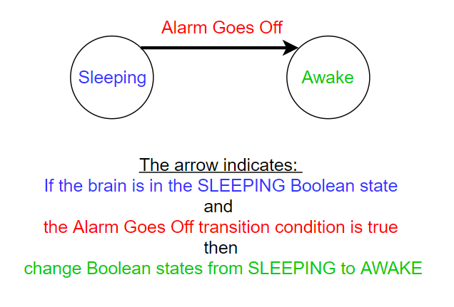

On a State Transition Diagram,the arrow from one state to another is a **State Transitions**. These arrows describe how the FSM changes states. The **Transition Conditions** represent the inputs or internal stimuli are needed to cause the states to transition. In this case it is the "Alarm Goes Off".

To better understand the difference between a **Transition Condition** and a **State Transition**, consider what would happen if the "Alarm Goes Off" when the brain is in the Awake state. Will it cause the brain to transition states again?

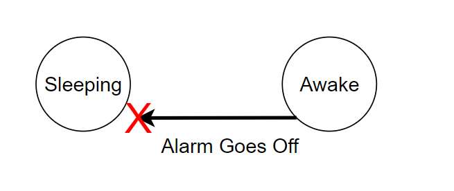

Thinking through the scenario, the alarm will not cause a state transition if already in the Awake Boolean state so we would NOT show an arrow from Awake to Sleeping for that conditoin.

It will quickly become difficult to fit all of the transition conditions as complete labels on our state transition diagram, so we will use shorthand labels to make the diagrams easier to read. Below is the complete state transition diagram for our brain model.

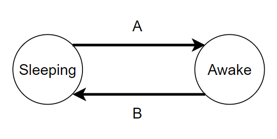

We'll use a **State Transition Table** to clearly define the state transitions and the transition conditions shown in the diagram.

### FSM: State Transition Tables

State transition tables are like a "key" that is used to read a state transition diagram. Each row represents a transition on the state transition diagram.

| Transition | Starting State | Condition | Ending State |
| --- | --- | --- | --- |
| A | Sleeping | Alarm rings | Awake |
| B | Awake | Bedtime and I'm tired | Sleeping |

Once this table is constructed, you can describe each entire transition from one state to another by reading across the table. For example, for transition B, we have:

"Transition B occurs when the state is 'Awake' and 'Bedtime and I'm tired' occurs."

### FSM: Latches

Consider our brain example. What happens when you are Awake and it is not bedtime?

You may think it's obvious that the brain should remain in the "Awake" Boolean state, but that possibility is not accounted for yet in our diagram and table. **For an FSM design to be complete, all logical possibilities must be accounted for in the state transition diagram.** This means that we have to be very explicit about when we stay in the "Awake" state and when we stay in the "Sleeping" state.

To keep an FSM in a Boolean state, you need to use a transition from a state back to itself. These state transitions are called **Latches.** They are a very special transitions that can make or break your FSM design. For some methods of implementing an FSM in code, latches are less important (an implementation based on a case/switch or if/else paradigm has "implied" latches, for example). However, in ES302, we will explicitly design and code every latch in our diagram to ensure that we will get the behavior we want from our FSM.

We can draw a latch state transition on our diagram the same way as any state transition arrow with the current Boolean state (at the beginning of the arrow) and the new state (at the point of the arrow) being the same!

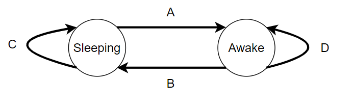

In the diagram above, we added state transitions "C" and "D", which are based on the logical statements in the table below. Note that the order in which you label the transitions, latches, and conditions is not important, but it helps to organize them for yourself so the table is easy to read and is quickly referenced.

[output not shown]

It's important to note that **the latch condition for each state covers all possibilities that the transition conditions out of that state did not.** This is because each time we "make a decision" about which state to be in, *we have to end up in one of our Boolean states!* For this simple two state model, it is possible to see by inspection we have covered all possibilities for all of the inputs and states of our state machine.

### FSM: OUTPUTS

In a FSM, what is considered an "output" is up to the engineer. Usually, an output is something that the machine uses to interact with its environment or its user... something observable to the outside world. Examples could be lights that indicate machine operation, signals that power motors or pumps, or text displayed on a user interface. One way to think about states is that they are "unique collections of system outputs."

What would the outputs be in our brain model?

We could assume that our brain model's only output is either open or closed eyes. So the eyes would be "open" in the awake state and they would be "closed" when in the asleep state.

**Outputs are not explicitly shown in a state transition diagram**, so you will need to keep track of which outputs belong to each state in your FSM model by writing them down separately.

If you wanted to make our brain model more realistic, you could add more outputs! You could add outputs based on each of the states (heart rate 70 when awake vs. heart rate 45 when asleep, etc.) without changing the *design* of the FSM as shown in the state transition diagram and table.

**FSM Designs are NOT unique!**

FSM designs offer the designer a lot of freedom. Your choice of states is just that-- a choice. As you move through the semester, you'll be asked to design FSMs to control the high-level operation of robots or of laboratory experiments. You may not always choose a "friendly" set of states, but don't despair! Practice will make you more and more adept at choosing a design that's simple but effective.

## FSM Implementation

### Boolean Algebra

In ES302, each "state" in your finite state machine will be represented in software by a Boolean variable. **A boolean variable is either true or false**. Therefore, the job of a FSM computer program is to make sure that when the one (and only one) variable that represents a state in your state transition diagram is true all others are false.

For example, let's consider the design of a [NHTSA Level 2](https://www.nhtsa.gov/technology-innovation/automated-vehicles-safety#topic-road-self-driving) automation system in a car, similar to what is available on a [Tesla Roadster](https://www.tesla.com/roadster). Say that you've designed the state machine governing whether the vehicle should maintain its lane, or change lanes to pass. Perhaps your diagram looks like the one below:

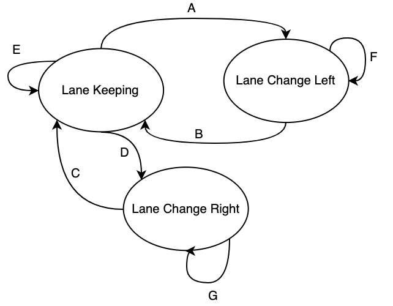

To implement this design, you would use a Boolean variable in your code to represent the truth value of each state. Maybe your variables are initialized as "LK," "LCL," and "LCR," to represent the three states in the diagram. The program's "main loop" will need to set **just one** of those variables true on each pass through the code, and make sure the others are false, in order to satisfy the fundamental assumption that a FSM can only be in one state at a time.

To make this actionable, we need to spend a little bit of time talking about how to create, evaluate, and code expressions using Boolean variables. In life, few things are "Black & White" or "True or False," but in the design of machines, two-state thinking is common. In the context of designing finite state machines, we use boolean algebra to write **Boolean Expressions** to represent whether a machine is in a particular state, and to represent the truth value of conditions, transitions, and latches.

This allows us to go from a *design* for a FSM in the form of a state transition diagram with transitions expressed in English to an actual computer program that keeps track of what state our FSM is in.

### Boolean Variables: two possibilities

It's possible to intuit the concept of a Boolean variable. Here are some example manifestations:

[output not shown]

All of these words are equivalent. In some programming languages (like Arduino), you can use "0" or "false" or "LOW" interchangeably to represent "false," and "1," "true," or "HIGH" to represent true. Many languages, however, are more restrictive. MATLAB (or its open-source equivalent, Octave), for instance, insists that Boolean variables are assigned a value of either "true" or "false" or "1" or "0," respectively.

See the code cell below for an example.

```python
a =True
b = False
c = not(a)

print(a,b,c)
```

```
True False False
```

#### But really, most things are not strictly off or on.

How do we deal with the ambiguity of "real life?" Mostly, we set "thresholds" for continuous variables that we wish to characterize with a Boolean "True" or "False." In digital circuits, such as the ones that make up your computer, logical "True" or "False" values like those that make up the bits of a binary number, are represented by voltages.

As you know from ES103 and/or ES201, voltage is a continuous quantity. Logic circuits deal with this by setting "thresholds" for what they consider a "False" voltage (close to 0), or a True voltage (close to 3.3V, 5V, 12V, etc. depending on the operating voltage of the circuit). Your house's thermostat also uses this concept. If you set your thermostat to 68 degrees Fahrenheit, your house's temperature control system will consider anything below 68 degrees to be "cold," and anything above 68 degrees to be "hot," even though as humans we have a much more nuanced outlook on temperature.

So although real-life is continuous, there is value in modeling these systems with Boolean behavior.

### Operations on Boolean Variables

The building blocks of "Boolean Expressions" are the basic logical operators "OR" "AND" and "NOT." A Boolean expression can be thought of as a statement of equivalence comprised of Boolean (true/false) variables,

#### OR

The "or" operator is often written as a "+" sign. Example: **"C is true if A or B is true"** can be written:

\begin{equation} C = A+B \end{equation}

In Arduino, we use "||" to represent "or" so the expression above would be coded as:

```
C = A||B;
```

In Python, we use "or" to represent "or," so the expression above would be coded as:

```
C = A or B
```

#### AND

The "and" operator is often written as a dot, $\cdot$, or ommitted entirely. Example: **"C is true if A and B are true"** can be written:

\begin{equation} C=A\cdot B \end{equation}

In some circles (including this class), the $\cdot$ AND symbol can be omitted so the expression $Y=A\cdot B$ is the same as the expression $Y=AB$.

In the Arduino language, we use "&&" to represent "and" so the expression above would be coded as:

```
C = A&&B;
```

In the Python language, we use "and" to represent "and" so the expression above would be coded as:

```
C = A and B;
```

#### NOT

The "not" operator is often written as a bar over an existing variable, e.g. $\overline{A}$. For example, the statement: **"C is true if A is not true"** can be written:

\begin{equation} C=\overline{A} \end{equation}

However, most programming languages do not allow you to use a $\overline{}$ sign to represent "not." In ES302, where we will use Python and Arduino (and maybe Matlab, if you wish), "not" is represented a bit differently-- either using an exclamation point, a tilde (~), or the word "not()." In an Arduino, we could write the following line of code:

```
C = !(A);
```

MATLAB and Octave use "~" to represent "not" so the expression above would be coded as:

```
C = ~A;
```

Python uses "not" to represent "not," so the expression above would be coded as:

```
C = not(A)
```

#### Common Symbols for Boolean Operations

The table below shows a summary of characters used for Boolean operators in different programming languages. It also includes the symbols use in other disciplines like philosophy.

Note that for "NOT," we include a "." to show that we are negating something. The "." is not part of the symbol(s).

[output not shown]

### Order of Operations

Formally, the order of operations for Boolean Algebra is:

1. NOT
2. AND
3. OR

**Note**: The "NOT" operator, denoted by the overline $\overline{.}$, has implied parentheses that span its length. Parentheses are used to group terms the same way as an overbar can be used, so parentheses and the "NOT" operator have equal precedence.

Much the same as it is in arithmetic and/or algebra. the "AND" ($\cdot$) operator takes precedent over the "OR" ($+$) operator, and parentheses can be used to group portions of an expression.

### Truth Tables

When we evaluate a Boolean expression, it's often necessary to look at all possible combination of **inputs** (variables on the RHS of the expression) and evaluate their corresponding **output** (assigned variable on the LHS of the equation) to understand the implications of subjecting the expression to all possible combinations of inputs. To do this, we use a tool called the **Truth Table**. For example, the truth table for the expression $C=A\cdot B$ is given below:

| $$A$$ | $$B$$ | $$C=A\cdot B$$ |
| --- | --- | --- |
| 0 | 1 | 0 |
| 1 | 0 | 0 |
| 0 | 0 | 0 |
| 1 | 1 | 1 |

Note that I needed to exhaust all possible combinations of the inputs in order to construct the table. As the number of inputs grows, so does the number of combinations you must test! In fact, there are $2^n$ combinations, where $n$ is the number of inputs in the expression!

Even with this complexity, truth tables are useful for testing more complex expressions "brute force." A good first example of this is the "XOR" or "exclusive OR" operator (shown as $\oplus$). This is like an "OR" operator but returns false if *both* A and B are true. By definition, the "XOR" operator is defined according to the following statement:

$$A\oplus B = \left(A+B \right)\cdot\overline{A\cdot B} $$

The procedure for constructing a truth table is simple. Create a column for each variable in the Boolean expression, and then create columns for intermediate steps in computing the expression according to the order of operations. Make certain that you exhaust all possibilities for combinations of inputs, or else the truth table will not be "complete."

| $A$ | $B$ | $A \oplus B$ | $A+B$ | $AB$ | $\overline{AB}$ | $\left(A\right. + \left.B \right) \cdot \overline{A\cdot B}$ |
| --- | --- | --- | --- | --- | --- | --- |
| 0 (false) | 0 (false) | 0 (false) | 0 (false) | 0 (false) | 1 (true) | 0 (false) |
| 1 (true) | 0 (false) | 1 (true) | 1 (true) | 0 (false) | 1 (true) | 1 (true) |
| 0 (false) | 1 (true) | 1 (true) | 1 (true) | 0 (false) | 1 (true) | 1 (true) |
| 1 (true) | 1 (true) | 0 (false) | 1 (true) | 1 (true) | 0 (false) | 0 (false) |

[output not shown]

The intermediate columns in the table above make evaluating the expression easier by grouping terms.

### Properties of Boolean Expressions

It is possible to evaluate any Boolean expression using a truth table, but it is long and tedious! Using a few simplification rules presented below make the job becomes much easier.

#### Commutative Property

\begin{equation} A\cdot B = B\cdot A \end{equation} \begin{equation} A+B=B+A \end{equation}

#### Associative Property

\begin{equation} \left(A\cdot B\right)\cdot C = A\cdot \left(B \cdot C\right) \end{equation} \begin{equation} \left(A+B\right)+C = A+\left(B+C\right) \end{equation}

#### Distributive Property

The AND operator can be distributed into an OR expression (just like multiplication into addition!)

\begin{equation} A\cdot \left(B+C\right)=\left(A\cdot B\right)+\left(A\cdot C\right) \end{equation}

#### Simplifying expressions: DeMorgan's Laws

DeMorgan's Laws, or the Laws of Negation, can be used to simplify long, complex Boolean expressions. It would be good practice to prove these using hand-written truth tables! Committing these to memory is actually quite usefule as they show up *a lot* in practical expressions common in logic-based programming and control (e.g. FSM design/implementation).

The first of DeMorgan's laws is one we like to call "neither!" It explains how to say that "neither A nor B can be true." \begin{equation} \overline{A+B}=\overline{A}\cdot \overline{B} \end{equation}

The second of DeMorgan's laws is one we like to call "Not this, or not that." It describes how to say that an expression is true if either A is false, or if B is false. Note that this is different than the case above, which says that neither A nor B can be true if the expression is to return true.

\begin{equation} \overline{A\cdot B} = \overline{A}+\overline{B} \end{equation}

### Example: Boolean Algebra Expression Simplification

Making use of these rules can help you simplify complex logic. Consider the following Boolean algebra expression.

\begin{equation} Y=A\left(\overline{A+B}\cdot B\right)+B \end{equation}

The truth table for this would be epic. However, if we make the simplification for $\overline{A+B}$, we see that we get:

\begin{equation} Y=A\left(\overline{A}\cdot\overline{B}\cdot B\right)+B \end{equation}

$B$ and $\overline{B}$ can never return true (B cannot be both true and false at the same time) so the whole parenthetical expression disappears, leaving us with $Y=B$.

## *FSM Implementation:* Jobs of a program that implements an FSM

You now know what a state machine is supposed to do conceptually: move a system from condition to condition (state to state) based on user inputs, sensors, and internal variables. Each state in our design, represented by a Boolean variable, must be set to either true or false in each program loop. As we design a state machine, we define "states" in our design by unique collections of outputs.

Based on its current state, the machine will also need to take some *action.* The action could be to illuminate lights on a display panel, activate motion of motors/pumps/solenoids, trigger some controlled subprocess in a robot like a "collision avoidance" strategy, or generate sound in the form of bells, whistles, or alarms.

Embedded in these various requirements is the reality that the *program* implementing the state machine has to do more than just evaluate logical statements for state transitions. In general, a complete program needs to:

- Handle/react to user inputs and sensors (read "pins" on an Arduino for instance)
- Update any internal variables (counters, timers) used in the state machine's logic
- Evaluate state transition logic to determine which of the transitions/latches in your state transition table is active (**there must always be exactly one true state at the end of each loop**).
- Update the machine's state based on the active transition or latch
- Use the current machine state to activate the appropriate outputs
- Store any variables from the "current" loop as "old" copies if they are needed in the next loop

THAT'S A LOT OF STUFF TO PLAN AND KEEP TRACK OF!. Additionally, the order in which we perform these sub-tasks matters... a lot. To make the planning/execution of complex state machine designs tractable, we will introduce a **Four-block Structure** we'd like you to follow when writing **Boolean Algebra programs** (state machine programs that operate using Boolean Logic statements). Following this structure is not strictly necessary to make your state machine program work, but it will help you avoid some common traps and make your code interpretable by anyone familiar with this framework.

## *FSM Implementation:* The Four-Block Structure

One possible way to organize a FSM implementation is by separating your state machine's code into four blocks, which are given below. Blocks 2 and 3 correspond directly with your state transition diagram and table, and blocks 1 and 4 are the interface between your FSM and the outside world.

Using this structure makes it very straightforward to turn your state transition diagram into a functioning FSM implementation. The structure is given below.

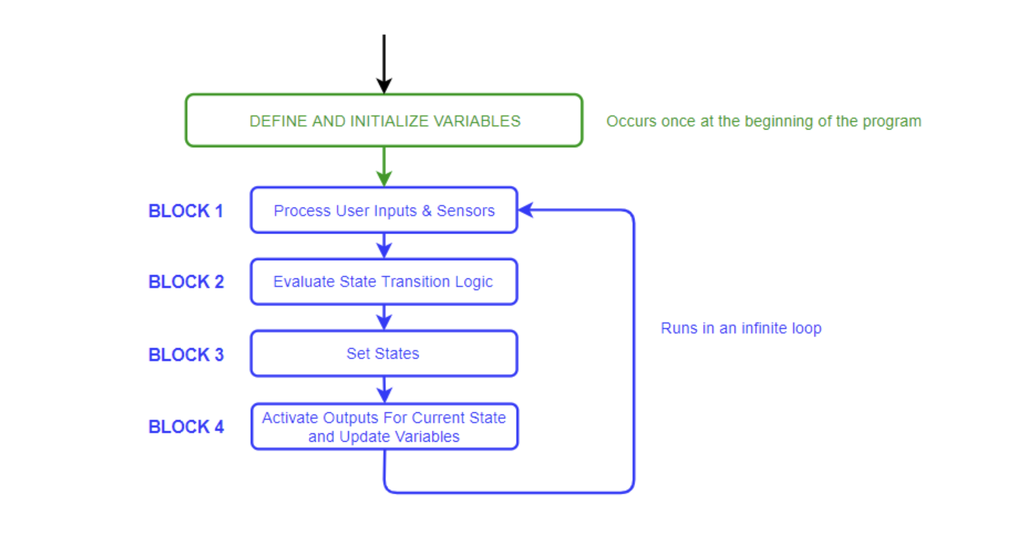

### Block 1: Process User Inputs & Sensors

Robots, factory assembly lines, CNC machines, handheld electronic games, HVAC systems, aircraft cockpits, and other automatic control systems whose operation can be supervised by a state machine usually have some way to interact with a human operator. Types of input devices are widely varied, but momentary switches and "latching" switches (toggle or locking switches like a light switch) are most common.

Block 1 is also where the program needs to take any "raw" inputs from the user and process/translate them for use in the state transition logic. For example, if your design requires you to hold a button for 2 seconds, you may need to write some logic that uses a "timer" (which we will cover later) to check how long a certain momentary button has been held.

#### Example - Unique Press

A common task that needs to go into this portion of your program is that of detecting a *unique press* on a momentary switch or button. Look at the time history of a momentary button press below:

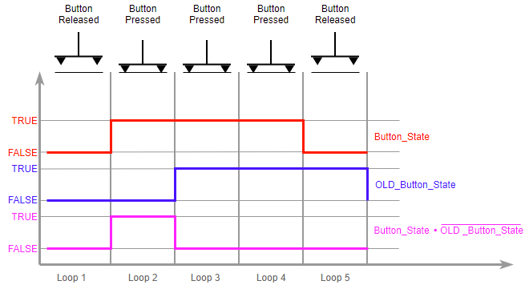

Each drawing of the button represents one pass or "loop" through the program logic. A Boolean Algebra Program implemented on a microprocessor often runs hundreds or thousands of times each second, so when a user presses a button just once, as shown in the figure above, the button's boolean state may read "TRUE" for more than one loop of the program, even though we humans can interpret the behavior shown as only a single *unique* button press. If your state transition logic depends on unique button presses, but your logic merely uses the Boolean variable "BUTTON_STATE," you may get unexpected behavior!

So how do we fix this problem? In the figure above, we see that the **rising edge** on the red "Button_State" trace is what is unique about the button press. In words, we can read a rising edge as follows:

"The button is pressed now, but it was not pressed the last time I looked at it."

As a logical statement, this would read something like:

$$BTN\_PRESS = Button\_State \cdot \overline{OLD\_Button\_State}$$

where OLD_Button_State is a stored value of what Button_State was in the LAST LOOP through the Boolean Algebra Program. Implemented as shown in this equation, the variable "BTN_PRESS" would have the time history shown in purple in the figure above. Note that it will only return "true" for one loop of the program even if the button is pressed, held, and released. In Arduino code, this might look like:

```
BTN_PRESS = Button_State && !OLD_Button_State;
```

In Python code, this might look like:

```
BTN_PRESS = Button_State and not(OLD_Button_State)
```

Of course, this is just one example of what "Block 1" of your program should contain. In summary, it needs to update the value of anything that will be used to evaluate the state transition logic in the next block.

### Block 2: Evaluate State Transition Logic

This portion of the program is the most critical to implement correctly, but can be the easiest to implement if you have carefully considered the design of your state transition diagram.

**To write the code for block 2, simply write a single line of code representing to the boolean expression for *each* transition in your state transition table *without including the ending state.* This means that in block 2, you should have as many lines of code as there are transitions in your state transition table.** This is a simple but extremely powerful way to make a quick self-assessment of the reasonableness of your block 2 code.

#### Block 2 Example

Let's consider a simple state machine that illuminates either a red light or a green light. If the machine is currently illuminating the green light, it will be in state "S1." If it is illuminating the red light, it will be in "S2." The machine will stay in its current state until the user registers a **unique press** on a momentary switch. When a unique press occurs, the machine will switch which light is illuminated. The state transition diagram for this machine is given below:

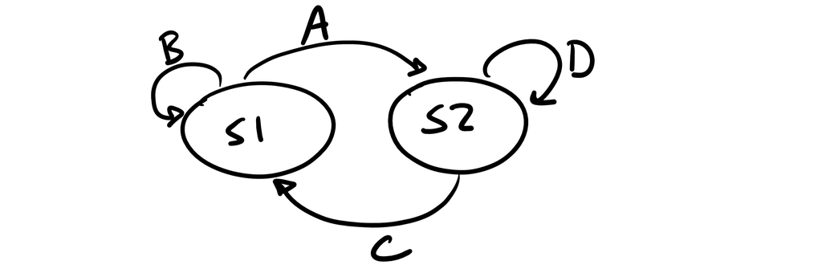

The state transition table for this machine is as follows:

| Transition | Starting State | Transition Condition | Ending State |
| --- | --- | --- | --- |
| 1: A | S1: Green State | $SW1\_PRESS$ | S2:Red State |
| 2: B | S1: Green State | $\overline{SW1\_PRESS}$ | S1:Green State |
| 3: C | S2: Red State | $SW1\_PRESS$ | S1:Green State |
| 4: D | S2: Red State | $\overline{SW1\_PRESS}$ | S2:Red State |

To implement block 2 for this finite state machine, we simply write a single line of code for each of the four rows in the state transition table. Remember that to do this, we read the table left to right, but we **do not include the ending state in the expression. We set a variable representing the __transition__ to either true or false, but we do not set the ending state to true or false just yet!**

In Arduino, you might write:

```
A=S1&&SW1_PRESS;
B=S1&&!SW1_PRESS;
C=S2&&SW1_PRESS;
D=S2&&!SW1_PRESS;
```

In Python, you might write:

```
A=S1 and SW1_PRESS
B=S1 and not SW1_PRESS
C=S2 and SW1_PRESS
D=S2 and not SW1_PRESS
```

These four lines together complete "Block 2" of our Boolean Algebra state machine program.

There are a few things that are important to notice about the logic above:

1. We do not actually **set the truth value** of any states in block 2. All we are doing is determining which transition in our design is true. Because of this, **variables representing a state SHOULD NEVER be on the left hand side of the equals sign in block 2**.
2. **Exactly one of these expressions must evaluate to true during one program loop! If none do, we will end up in no state at all, and if multiple transitions evaluate to true, we will end up in more than one state!**
3. The transition *conditions* are redundant (2 are SW1_PRESS and 2 are !SW1_PRESS) but the *state transitions* themselves are unique, because they contain information about the current (starting) state, which is the "context" for the transition.

While items 2 and 3 are fairly self explanatory, number 1 in the list above bears some extra explanation, so let's consider a counterexample.

Imagine that I tried to directly set the ending states in block 2. Perhaps I thought to myself "why not cut out the extra steps? The table tells me where I'm supposed to end up. That should work!"

This attempt might look like the following:

```
S2=S1&&SW1_PRESS;
S1=S1&&!SW1_PRESS;
S1=S2&&SW1_PRESS;
S2=S2&&!SW1_PRESS;
```

Look carefully at this block of code, and imagine the following scenario: I'm in state 1 and push the button to get into state 2. Evaluating the first line of the program, I see that because S1=true and SW1_PRESS=true:

`S2=S1&&SW1_PRESS;` evaluates to TRUE

But then when I evaluate line 3, and I see that because S2 is now true, and because SW1_PRESS is **still** true:

`S1=S2&&SW1_PRESS;` evaluates to TRUE

so the machine "instantaneously" switches back into state 1, where I started!

This is called "falling through" the logic, and it's exactly why we only set the truth values of *intermediate variables* that represent the state transitions in Block 2 rather than setting the truth value of the states just yet. As a reminder, the correct block 2 for our design is given by:

```
A=S1&&SW1_PRESS;
B=S1&&!SW1_PRESS;
C=S2&&SW1_PRESS;
D=S2&&!SW1_PRESS;
```

Because we are using the "extra" variables to represent the state transitions **The order of the individual lines of code in block 2 is unimportant!**

In the correct implementation, we aren't prematurely setting S1 to true before we **finish** evaluating the transition logic. You can think of these "transition variables" as "queuing up" the move from one state to another, but deferring the **actual** move until all transition possibilities are evaluated.

Combining the "block 1" example above with our correct block 2, we currently have a Boolean Algebra Program that looks like this in Arduino:

```
//block 1
SW1_PRESS = SW1&&!SW1_OLD;
//block 2
A=S1&&SW1_PRESS;
B=S1&&!SW1_PRESS;
C=S2&&SW1_PRESS;
D=S2&&!SW1_PRESS;
```

or like this in Python:

```
#block 1
SW1_PRESS = SW1 and not SW1_OLD
#block 2
A=S1 and SW1_PRESS
B=S1 and not SW1_PRESS
C=S2 and SW1_PRESS
D=S2 and not SW1_PRESS
```

This procedure, if followed rigorously, will eliminate almost all of the frustration and heartache that can accompany state machine programming. You can follow the same procedure outlined here for any arbitrarily complex state machine, and it will still work.

Let's move on to a talk about Block 3, which takes our **transition variables** and uses them to set the proper state for the state machine.

### Block 3: Set States

This section of code will finally "decide" which of our states will be true for this loop of the program. We look to the **diagram** to determine how to use the state transitions to set our current state. Specifically, we look at each state in our diagram and count the number of arrow heads pointing at it. Each arrow, as we know, represents one of the *transition variables* we defined in block 2. So all that is required now is to write the logic to say that a state is true if any of the state transitions ending in that state are true.

Functionally, this might manifest in Arduino for a single state as:

```
State_x = T1||T2||T3;
```

or like this in Python:

```
State_x = T1 or T2 or T3;
```

#### Example

For the same program we were working on above, the Block 3 logic would look like this in Arduino:

```
S1=B||C;
S2=A||D;
```

and like this in Python:

```
S1=B or C;
S2=A or D;
```

Notes:

1. All of the *rows of the table* are used in block 3. This is the same as the number of arrows on your state transition diagram.
2. Block 3 has as many lines of code as there are states in your diagram.
3. Because our state transition diagram and table **cover all logical possibilities for the state machine**, our machine will end up in either the red or the green state after each loop. So far, then, our complete Boolean Algebra Program is given by the following in Arduino (excluding variable declarations/initializations):

```
//block 1
SW1_PRESS = SW1&&!SW1_OLD;
//block 2
A=S1&&SW1_PRESS;
B=S1&&!SW1_PRESS;
C=S2&&SW1_PRESS;
D=S2&&!SW1_PRESS;
//block 3
S1=B||C;
S2=A||D;
```

or like this in Python:

```
//block 1
SW1_PRESS = SW1 and not SW1_OLD;
//block 2
A=S1 and SW1_PRESS;
B=S1 and not SW1_PRESS;
C=S2 and SW1_PRESS;
D=S2 and not SW1_PRESS;
//block 3
S1=B or C;
S2=A or D;
```

Now that the variables S1 and S2 are properly updated for this loop of our program, we will move on to Block 4, which uses the current (updated) state to activate any appropriate outputs.

### Block 4: Activate Outputs For Current State and Update Variables

This (final) part of your Boolean Algebra program is fairly self-explanatory. Now that I know which state my machine is in, I'll use that information to activate any outputs (lights, sounds, motors, pumps) that are associated with this state. Because I'm "finished" with all of the program's tasks, I'll store the current state of relevant variables in an "OLD" variable so I will be able to access in the next loop of the program *after* inputs have been updated. In this case, we just need to store the "OLD" value of SW1 so that we can detect unique presses.

#### Example

For the two state example we've been working in this notebook, the outputs are a red light and a green light. Let's assume that setting the variable "Y1" to true makes the green light turn on, and setting "Y2" to true makes the red light turn on. This yields the following (almost) complete Boolean algebra program for our example in Arduino language:

```
//block 1
SW1_PRESS = SW1&&!SW1_OLD;
//block 2
A=S1&&SW1_PRESS;
B=S1&&!SW1_PRESS;
C=S2&&SW1_PRESS;
D=S2&&!SW1_PRESS;
//block 3
S1=B||C;
S2=A||D;
//block 4
Y1=S1;
Y2=S2;
SW1_OLD=SW1;
```

And in Python:

```
#block 1
SW1_PRESS = SW1 and not SW1_OLD
#block 2
A=S1 and SW1_PRESS
B=S1 and not SW1_PRESS
C=S2 and SW1_PRESS
D=S2 and not SW1_PRESS
#block 3
S1=B or C
S2=A or D
#block 4
Y1=S1
Y2=S2
SW1_OLD=SW1
```

### What about "if" statements? Switch-Case statements? This isn't how I learned to program FSMs in another class!

#### If-statements

If you have some programming experience, you may be wondering why we wouldn't just use "if" statements for determining the FSM state in blocks 2 and 3. The reason I do not teach that is because using Boolean Algebra directly is much more compact, easier to read, and more efficient. Let's look at one of the Block 2 lines above in the Arduino language for example.

```
//block 2
A=S1&&SW1_PRESS;
```

That one line will set "A" to true if the expression evaluated to true, and will set "A" to false if the expression evaluates to false. Let's take a look at how we would accomplish the same thing in the Arduino language using "if" statements.

```
//block 2
if(S1&&SW1_PRESS){
    A = true;
}
else{
    A = false;
}
```

As you can see, using an if-statement *can* accomplish the same thing, but in a much more convoluted way that is more difficult to read. If we were incrementing integer variables, doing float operations, etc. directly based on the truth value of the transition "A" then we would *need* to use an "if-else" paradigm, but because all we're doing is setting a Boolean variable to true or false, an "if-else" flow control statement is cumbersome and unnecessary.

The explanation above should make you wonder about block 4. What if you need to call functions to activate motors based on your robot's state? What if you need to use non-boolean variables in your outputs? Would you use "if" statements then? **YES!** If-statements are perfectly acceptable for Blocks 1 and 4 if you need to take action on non-Boolean variables.

#### Switch-Case statements

You may see implementations of FSMs in your travels (or on the internet) that are based on the "switch-case" paradigm. This is a really cool way to do it, and there's nothing inherently "bad" about doing it this way. So why don't we learn it in ES302?

The issue with learning to design FSMs this way is that switch-case statements are available in some languages (like [arduino](https://www.arduino.cc/reference/tr/language/structure/control-structure/switchcase/)) but not in others (like Python). Developing fluency in programming FSMs that generalizes between programming languages is powerful. Heck, because you're learning to program FSMs with Boolean variables, you could even build an FSM using no programming language at all, and make it out of [relays](https://www.youtube.com/watch?v=n3wPBcmSb2U) instead!

# FSM Implementation: Implementation in object-oriented languages (Python)

If you are implementing an FSM in Python or C++ (Arduino), you have the option of wrapping some or all of your Boolean Algebra Program (for example, blocks 2 and 3 of the 4-block structure) in a class to avoid needing to carry lots of extraneous global variables around in your robot's code. This will also allow you to "port" your FSM code between a simulated robot and a real one, for example, since your FSM will be a unique "class" that can be instantiated in different embodiements of your robot. Please see the python resource for more information on writing classes in Python. We will not be covering how to write an "arduino library" with classes in ES302, but documentation for doing so is available online.

In the interest of writing code that your classmates can understand, critique, and help you with, we will implement a structure for writing the FSM itself (blocks 2 and 3 of a 'Boolean Algebra Program') as a class. The class's members should be your states, and its methods should at the very least include an "update()" method that runs blocks 2 and 3 of the four-block structure. Our example from this notebook can be coded as follows:

```python
class TwoStateFSM:
    #this method runs automatically when the class is instantiated:
    def __init__(self):
        #define our state variables
        self.S1 = True #we will start in state S1
        self.S2 = False #we can only be in one state at a time!
    #this method runs blocks 2 and 3 and "updates" the machine's state
    def update(self,SW1_PRESS):
        #the transition variables do not need to be class-owned (old values not important). We only need them for this loop.
        #block 2
        A=self.S1 and SW1_PRESS
        B=self.S1 and not SW1_PRESS
        C=self.S2 and SW1_PRESS
        D=self.S2 and not SW1_PRESS
        #block 3
        self.S1=B or C
        self.S2=A or D
```

Now let's say we want to test this machine. Its expected behavior is that when we press the switch and hold it, the machine transitions from state S1 to state S2 **once** and stays in S2. Then, when we see a second **unique press** of SW1, the machine will transition back to state S1 **once.** We can create a variable that represents a time history of SW1 that allows us to test this.

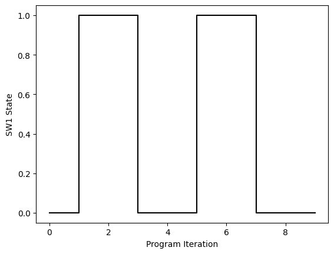

```python
import matplotlib.pyplot as plt

#create a vector representing a possible time-history of the switch's truth value
SW1_vector = [False,False,True,True,False,False,True,True,False,False]

#plot this so we can visualize it
plt.figure()
plt.step(range(len(SW1_vector)),SW1_vector,'k')
plt.xlabel('Program Iteration')
plt.ylabel('SW1 State')
plt.show()
```

now let's imagine we wrote a piece of robot code that runs as a quasi-infinite loop, making decisions at every "moment." We can simulate this by looping through our time-history for SW1's state above, and applying SW1's state as the input to our FSM.

```python
import numpy as np
#create an instance of our TwoStateFSM class
fsm = TwoStateFSM()

#create an "old" value for our switch press
SW1_old = False

#create a vector to hold the results of our test:
results = np.zeros((len(SW1_vector),4),dtype=np.bool)

#create a loop that simulates an "infinite" loop that runs the robot:
for k in range(0,len(SW1_vector)):
    SW1 = SW1_vector[k]
    #block 1: we already "read" the truth value of SW1. In hardware, this might be some kind of read() function
    #but we need to determine whether we've had a unique press on SW1 in order to send this to the FSM
    SW1_press = SW1 and not SW1_old
    #blocks 2 and 3 handled by the FSM object
    fsm.update(SW1_press)
    #block 4: set outputs based on our states.
    Y1 = fsm.S1
    Y2 = fsm.S2
    #block 4: set 'old' SW1 value to help detect rising edges
    SW1_old = SW1
    #print our results so we can evaluate our FSM model
    results[k,:] = np.array([SW1,SW1_press,Y1,Y2])

iterations = range(0,len(SW1_vector))
#plot our results:
plt.figure(figsize=[10,8])
plt.subplot(411)
plt.step(iterations,results[:,0],'k')
plt.ylabel("SW1")
plt.subplot(412)
plt.step(iterations,results[:,1],'k')
plt.ylabel("SW1_press")
plt.subplot(413)
plt.step(iterations,results[:,2],'k')
plt.ylabel("S1/Y1")
plt.subplot(414)
plt.step(iterations,results[:,3],'k')
plt.ylabel("S2/Y2")
plt.xlabel("Program Iteration")

plt.show()
```

[output not shown]

[output not shown]

# FSM Implementation: An Introduction to Timers and Rising Edge Counters

## Timers

In many applications where a FSM is a good choice for high-level program operation, you'll find yourself needing to design your state machines' transitions to use a few common stimuli. For instance: if you need to create a system that "waits" for a specified period of time after a button is pressed, or requires that a button is pressed for a particular length of time to "make sure" that the user meant to enter a particular machine state, you'll likely need to implement (or use) some kind of **timer** so that the stimulus of "wait for a specified amount of time" can be implemented in your state transition diagram and chart.

Timers are extremely common in finite state machine design. You can program them many ways, but in general, they have the following behavior:

- When the boolean input to the timer is TRUE, the timer counts up (usually in milliseconds).
- When the elapsed time is greater than some threshold (called the 'preset'), the timer's output variable is set to TRUE. Otherwise it is FALSE.
- When the input to the timer is FALSE, the timer stops counting and the elapsed time is *reset* to zero.

You can program a timer in Python as an Object as follows:

```python
class Timer:
    def __init__(self,preset):
        #current "state" of the timer
        self.state = False
        #current elapsed time
        self.elapsed = 0
        #timer will go true if it has counted for more than 1 second
        self.preset = preset
    def update(self,ENABLE,dt):
        #dt is the timestep by which we should count up. make sure its units match your preset!
        #don't set the preset in seconds and increment the elapsed time in milliseconds, for example!
        #ENABLE is a boolean. When it is true, we run up the timer. When it is not, the time resets and we stop counting.
        if(ENABLE):
            #increment time by dt
            self.elapsed+=dt
            self.state=self.elapsed>=self.preset
        else:
            self.elapsed=0
            self.state=False
```

We can (and should) "unit test" this timer. Let's use a simple code to do this.

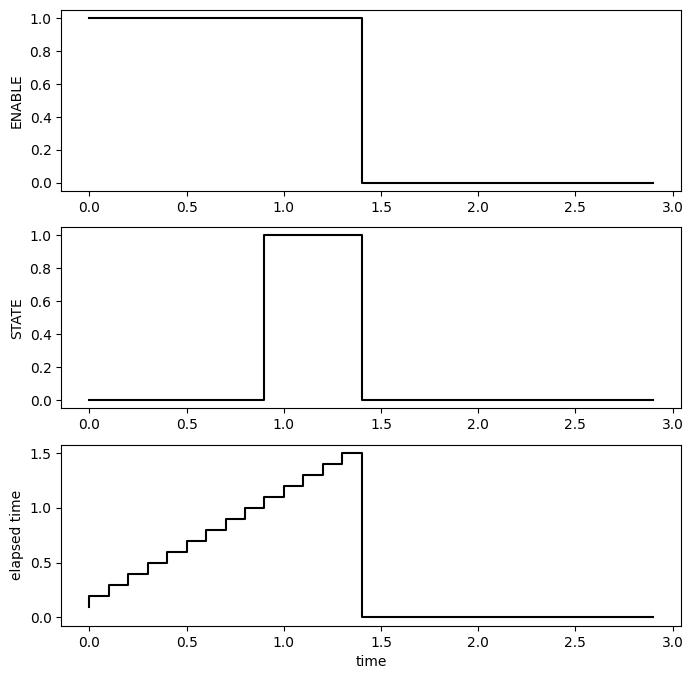

```python
import numpy as np
import matplotlib.pyplot as plt

dt = .1
#time vector
t = np.arange(0,3,dt)
cols = np.size(t)
#vector of ENABLE states
en = np.zeros(np.size(t))
#set the first half of these to 1
en[0:int(cols/2)] = 1

#create timer object
tmr = Timer(1.0)#1.0 second preset

#now run through time, operating the timer according to en
#saving results in an array
results = np.zeros((3,cols))

for k in range(0,cols):
    #run the timer.
    tmr.update(en[k],dt)
    #save results in a vector to plot later
    results[:,k] = np.array([en[k],tmr.state,tmr.elapsed])

plt.figure(figsize=[8,8])
plt.subplot(311)
plt.step(t,results[0,:],'k')
plt.ylabel("ENABLE")
plt.subplot(312)
plt.step(t,results[1,:],'k')
plt.ylabel("STATE")
plt.subplot(313)
plt.step(t,results[2,:],'k')
plt.ylabel("elapsed time")
plt.xlabel("time")
```

Notice that the timer starts counting right away. The status bit "state" goes true after the elapsed time reaches 1 second, and once ENABLE goes false, the timer stops counting and everything is reset!

Now imagine using this timer object in conjunction with an FSM! You could make the timer count up when the fsm is in a particular state, and use the timer's status bit "state" as an input that triggers state transitions!

## Rising Edge Counters

A rising edge counter helps a finite state machine keep track of how many times something has happened. This, like a timer, is a common need for designing the stimuli for transitions in FSMs. A standard counter that you might find on an industrial controller has three inputs: an "up input," a "down input," and a "reset input." We will model our counters after this type.

- If the user (or the state transition logic) sets the "up" input true with a *unique rising edge* (was false, now true-- like a button press), an internal variable (integer) in the counter will count up by one.
- If the using input sets the "down" input to be true with a "unique rising edge",it will bring the count (the counter's "accumulator") down by one. Generally, counters have a minimum value of 0.
- Whenever the "reset" input on the counter is true, the count is resets to zero.
- When the counter's accumulator reaches a preset value the output variable is set to TRUE. Otherwise it is FALSE.

We can program a class that implements a rising edge counter in Python as follows:

```python
class RisingEdgeCounter:
    def __init__(self,preset):
        self.preset = preset
        self.count = 0
        self.up_old = False
        self.down_old = False
        self.state = False

    def update(self,up,down,reset):
        up_edge = up and not self.up_old
        down_edge = down and not self.down_old

        if(not reset):
            if(up_edge):
                self.count+=1
            if(down_edge):
                self.count-=1
            #limit the counter so it can not count negative
            if(self.count<=0):
                self.count = 0
            self.state = self.count>=self.preset
        else:
            self.state=False
            self.count=0
        #reset old variables
        self.up_old = up
        self.down_old = down
```

As we did before, we should test this counter implementation to ensure that it behaves as we expect. We can do this by creating a simulated time-history for the counter's inputs up, down, and reset.

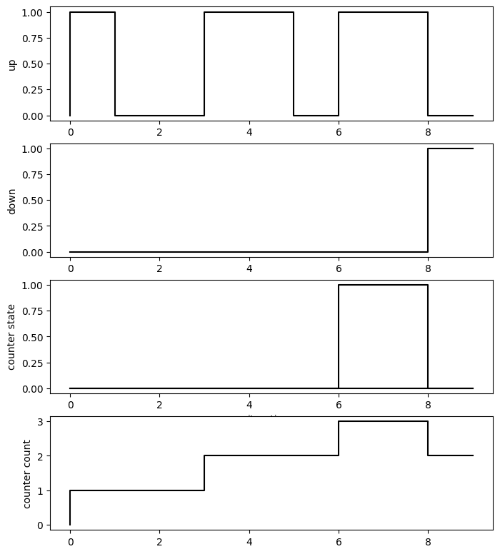

```python
import numpy as np
import matplotlib.pyplot as plt

iterations = 10#run program for 10 fake iterations
up_vec = [False,True,False,False,True,True,False,True,True,False]
down_vec = [False,False,False,False,False,False,False,False,False,True]
reset_vec = [False,False,False,False,False,False,False,False,False,False]

#create a counter
ct = RisingEdgeCounter(3)#preset of 3

#saving results in an array
results = np.zeros((5,iterations))

for k in range(0,iterations):
    #run the counter
    ct.update(up_vec[k],down_vec[k],reset_vec[k])
    #save results in a vector to plot later
    results[:,k] = np.array([up_vec[k],down_vec[k],reset_vec[k],ct.count,ct.state])

its = range(0,iterations)
plt.figure(figsize=[8,12])
plt.subplot(511)
plt.step(its,results[0,:],'k')
plt.ylabel("up")
plt.subplot(512)
plt.step(its,results[1,:],'k')
plt.ylabel("down")
plt.subplot(513)
plt.step(its,results[2,:],'k')
plt.ylabel("reset")
plt.subplot(514)
plt.step(its,results[3,:],'k')
plt.ylabel("counter count")
plt.subplot(513)
plt.step(its,results[4,:],'k')
plt.ylabel("counter state")
plt.xlabel("iterations")
```

# Controller Validation: Timers and Rising Edge Counters in Arduino

In ES302, we will primarily be programming robots using Python. However, many small robots use Arduino (C++) or another compiled language and have no way to be programmed in a high-level interpreted language like Python. The ME480 instructors at Lafayette (ME480 is a control systems/mechatronics course that focuses on embedded systems that use Arduino) have created an Arduino Library ([what is that?](https://www.arduino.cc/reference/en/libraries/)) for you that implements the functionality of built-in counters and timers that you can use in your finite state machines. That library is available [here](https://github.com/Alexanderallenbrown/ME480FSM)

To validate our understanding of how timers and rising edge counters can be implemented on Arduino, you can use one of the Romi robots in the robotics lab.